# Reproducible, AI-assisted modeling and data science (MDS) projects

Andreas Handel

2026-09-08

## Overview

01**Concept**What makes a project organized, reproducible, and ready for responsible AI?

02**Implementation**A setup that turn those ideas into a practical working environment.

03**Details**How does the template work, and what should a new project do first?

## Concept

Part 1

Concepts of reproducible project workflows

## Motivation

- Reproducibility is a hallmark of good science
- A well-organized, reproducible project often makes work more efficient
- AI supported work is the future (present)

## Problems with “standard” workflows

**Results drift from their code**Copied tables and figures become hard to update or verify.

**Files lose their roles**Raw, processed, current, and obsolete versions become difficult to distinguish.

**Decisions disappear**Cleaning and modeling choices remain in memory or private conversations.

**Sharing becomes risky**Private data and unfinished material move into unsuitable places.

**Reproducibility is hard**Others (including your future self) will struggle reproducing your work.

## The ORDERly concept

Organized + Recorded + Documented + Executable = Reproducible (**ORDER**ly).

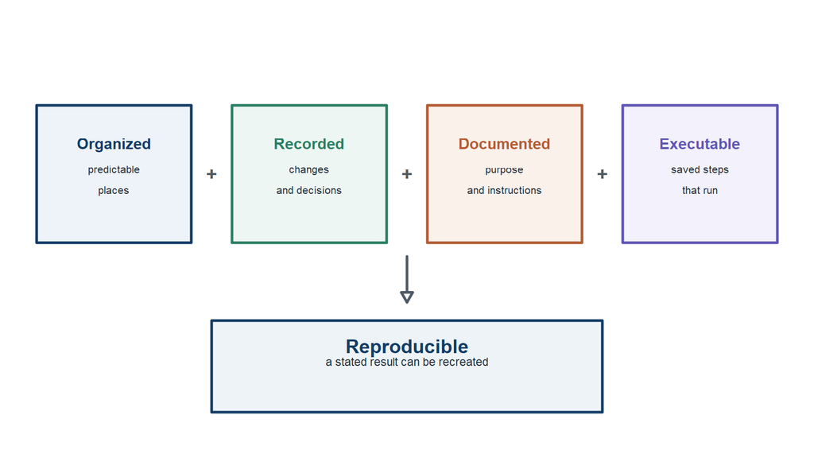

## AI support needs to be managed

- Organization
- Restrictions
- Documentation
- Evaluation

can preserve reproducibility.

## Human judgment remains the gate

**Science**Are the data, model, assumptions, and interpretation appropriate?

**Governance**May these data, documents, and systems be used with this AI tool?

**Acceptance**Does the change work, and can the project owner explain and defend it?

## Implementation

Part 2

Implementation

Tools to support an AI assisted ORDERly workflow.

## The components

- A structured template (as GitHub repository)
- A set of tools that support ORDERly workflows
- Tools are largely interchangable, but text-based, easy to track tools are best (avoid Excel, Word, etc.)

## Specific tools

- IDE, e.g. Positron, VS Code, RStudio
- Coding language(s), e.g. R, Python, Julia
- Authoring software, e.g. Quarto or Typist
- Tracking tools, e.g. Git/GitHub
- agentic AI tools, e.g. ChatGPT Codex, Claude Code

## Details

Part 3

Template details and first steps

## The repository map gives each part a role

The main path moves through data, code, results, and products; support folders provide stable inputs and guidance.

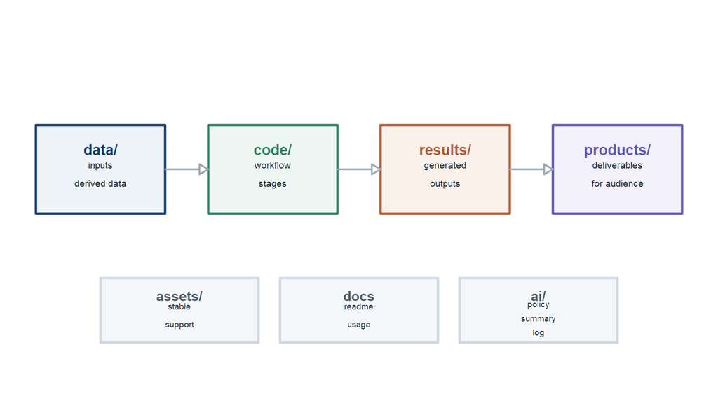

## Separate raw, derived, private, and large data

**raw-data/**Original input; preserve it unchanged.

**processed-data/**Cleaned or transformed data generated by code.

**private-data/**Restricted material kept in an approved location.

**large-files/**Material too large for ordinary Git and GitHub use.

## Code follows the stages of the analysis

Each stage should have recognizable inputs, outputs, and instructions.

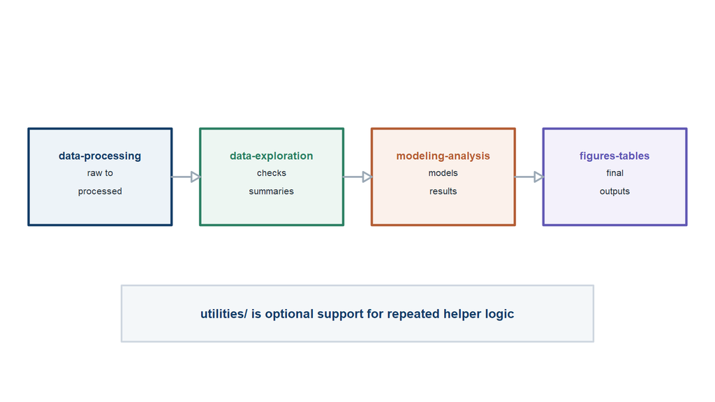

## Keep generated outputs separate from supporting inputs

**results/**Code-generated model objects, intermediate outputs, figures, and tables.

**products/**Reports, manuscripts, supplements, presentations, posters, and apps.

**assets/**References, PDFs, schematics, and other stable supporting material.

**ai/**AI policy, project context, guidance, and meaningful-use records.

## Run the workflow in clear stages

1**Process**raw → processed

2**Explore**checks + summaries

3**Analyze**models + results

4**Prepare**figures + tables

5**Render**reports + slides

Regenerate results before updating the products that use them.

## Check the project before accepting or sharing it

**Inputs**Was raw data preserved and sensitive material kept in approved locations?

**Traceability**Can each important output be connected to code and documented inputs?

**Execution**Does the workflow run from a fresh session or clean copy?

**Communication**Do instructions, paths, figures, tables, and interpretations match?

## A useful project is easy to continue

**Current you** can work efficiently.

**Future you** can recover the reasoning.

**Collaborators** can review and extend the work.

**Others** can understand and recreate the stated result.

Make the workflow ORDERly. Let the template carry the structure.

## Getting started

- Visit the template repository: https://github.com/andreashandel/mds-project-template
- Read the ‘Readme’ file on the main page.
- Follow the instructions provided in the `Readme` and further documents.
- Update the guidelines as needed.
- Involve AI early on, make sure all is documented.

## Further Extensions

- Include more sophisticated package or workflow management (e.g. ‘renv’, ‘Docker’,‘targets’)

## Continue learning

**MDS tools mini-courses**andreashandel.github.io/mds-tools/

**Inside the template**`readme.md` · `usage.md` · `new-project-instructions.md`